# Data exploration and basic plotting

Elizabeth Oladapo

Last modified: 10 Oct 2023

In this section, we will focus on loading data into R and saving files into your project directory and sub directories, exploring data and basic plotting of graphs.

### 1. Download the datasets

Download all the datasets we will be using in this course:

[R_course_datasets](https://drive.google.com/drive/folders/17glWVCgvnoTAPKUdcdO_MhCXSSCmQO6P?usp=sharing)

Move the .csv files into the data folder in your project folder (“R-training”) on your local machine

### 2. Importing data from the data folder into R

Any .csv file can be imported into R using the function read_csv() and assigning it to a new variable to store the data from the file.

Prior to loading your data, make sure to load the required libraries for this section and set up you script with appropriate annotations

**Something to note**: Always annotate your code (with # and break into sections with # and ——) so that when you look back on what you have coded. You understand in detail what a line, chunk or even section of code is trying to accomplish.

```r
### Data Management and Basic graphing (* you can create a section or chapter by putting "----" @ the end of this line)
### Elizabeth Oladapo
### 13 February 2023

# Analyzing the data on 288 African elephants that lived through droughts in the first two years of life.
# The data contains 3 variables and 288 observations.
# The variables are; Age, Height and sex

##Source:
# Data are from Phyllis Lee, Stirling University, and are related to Lee, P., et al. (2013), "Enduring consequences of early
# experiences: 40-year effects on survival and success among African elephants," Biology Letters, 9:
# 20130011.

# Load the packages I need with the function library()

library("tidyverse") #tidyverse imports ggplot2 and dplyr
```

A check can be performed with the function file.exists() which will print TRUE if the file is present in the working directory.

```r
file.exists("data/ElephantsMF.csv")
```

```
## [1] TRUE
```

Now that the file exists in the working directory, we will need to import it into R to start making R work hard on it.

Import the ElephantsMF.csv file and assign it to a variable name called “Elephants_data”

```r
# Loading the required data

Elephants_data <- read_csv("./data/ElephantsMF.csv")
```

Look at the data using the function glimpse(), to be sure you have loaded the correct data

A basic dataframe organizes data into a two-dimensional grid of rows and columns, much like a spreadsheet. In general, we will refer to the rows of the dataframe as observations, and the columns as variables.

```r
# Looking at the data

glimpse(Elephants_data)
```

```
## Rows: 288
## Columns: 3
## $ Age    <dbl> 1.40, 17.50, 12.75, 11.17, 12.67, 12.67, 12.25, 12.17, 28.17, 1~
## $ Height <dbl> 120.00, 227.00, 235.00, 210.00, 220.00, 189.00, 225.00, 204.00,~
## $ Sex    <chr> "M", "M", "M", "M", "M", "M", "M", "M", "M", "M", "M", "M", "M"~
```

```r
# or just Elephants_data
# or use "str(Elephants_data)"  to show the 'factors' and 'levels' info in output for characters.
# Some R version will require that you convert the character variable to factor as seen below,
# for str() to show "factors" info.

# Elephants_data$Sex <- as.factor(Elephants_data$Sex)
```

```
Question 1

There are three variables in the Elephants_data, which of them seem like the explanatory variables and which one is likely to be the response variable?
```

### 3. Visualizing the data

Visualize the data by generating your first plot in R using the function ggplot() from the package, ggplot2.

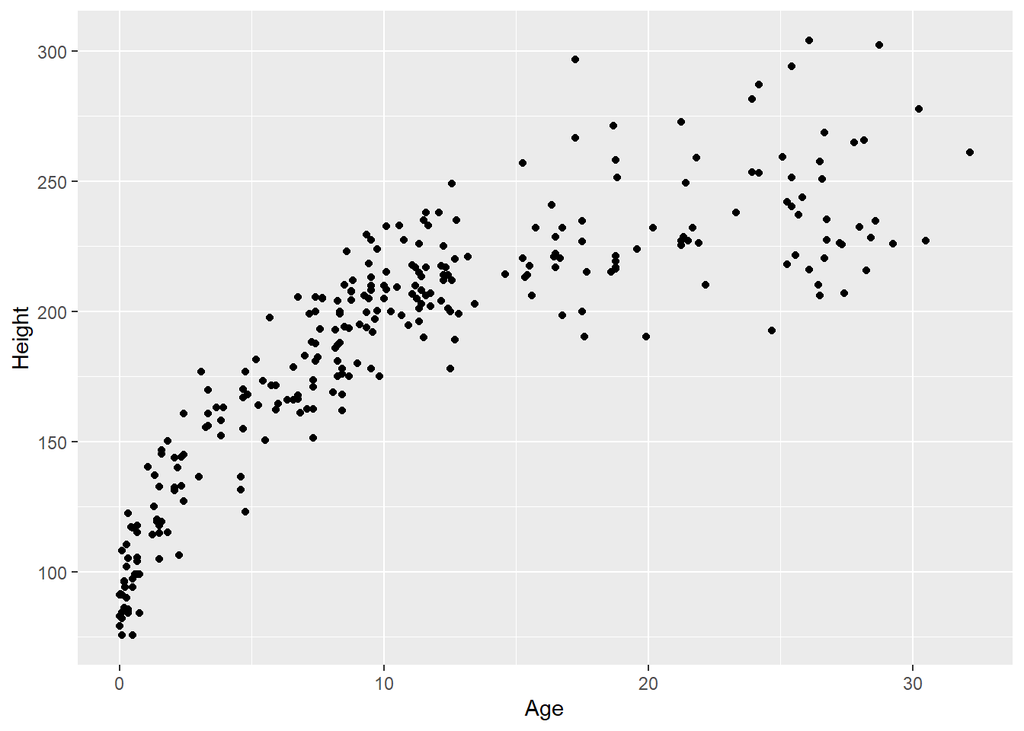

```
Question 2

What is the relatioship between height and age? any interaction with age groups (below 20 and above 20)?
```

```r
## Visualize data with scatterplot

ggplot(Elephants_data, aes(x = Age, y=Height))+
  geom_point()    # a continuous response variable with a continuous explanatory variable producing scatterplot
```

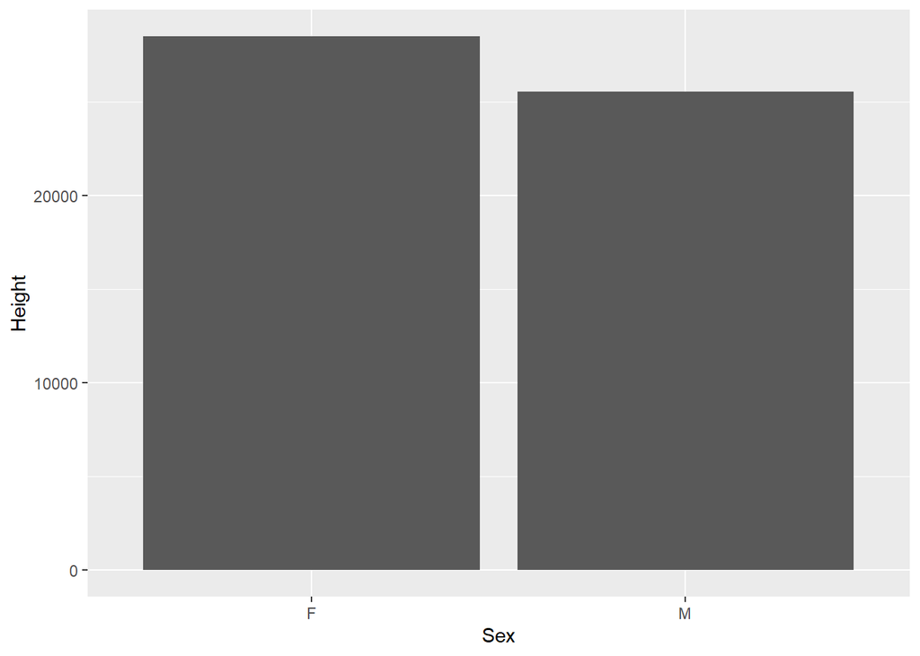

```r
## Visualizing data with a barchart

ggplot(Elephants_data, aes(x = Sex, y=Height))+
  geom_col()    # a continuous response variable with a binary explanatory variable producing barcharts
```

### 4. Customizing the plot

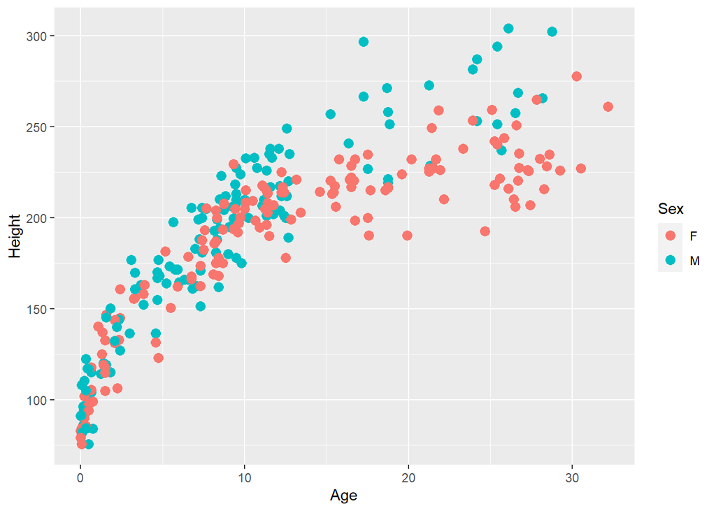

```r
## Visualizing the data

ggplot(Elephants_data, aes(x = Age, y=Height, colour = Sex))+
  geom_point(size = 3)    # a continuous response variable with a continuous explanatory variable producing scatterplot
```

### 5. Manipulating data

We can use several functions in the package, dplyr to explore and manipulate the data.

Please note that it is possible to use the functions in the The [R Base Package](https://stat.ethz.ch/R-manual/R-devel/library/base/html/00Index.html) (This package contains the basic functions which makes R a language: arithmetic, input/output, basic programming support, etc. Its contents are available through inheritance from any environment.). However, it is generally easier to read, manipulate and write data using dplyr.

We will be covering some of the functions available in the dplyr here. You can get an overview of most functions in dplyr [cheatsheet](https://www.rstudio.com/wp-content/uploads/2015/02/data-wrangling-cheatsheet.pdf).

**Note:** Mostly, observations are in the rows and variables are in the columns

**Subsetting Variables: Columns**

The variables in our data are Age, Height and Sex as you can see in the environment pane or using the function glimpse().

We can access the columns of a data frame using the select function.

“select()” from dplyr grabs specific columns and works only with variables

We can select column by name, by adding bare column names (i.e. not requiring quote marks around the name) after the name of the data frame, separated by a ” , “.

Make sure to type the name exactly as it appears in the data. If select sees a name that doesn’t exist in the data frame it will give an informative message Error.

Again, check what select does from the [cheatsheet](https://www.rstudio.com/wp-content/uploads/2015/02/data-wrangling-cheatsheet.pdf).

```r
## subsetting columns
# select the "Age" variable from the Elephants_data

select(Elephants_data, Age)
```

```
## # A tibble: 288 x 1
##      Age
##    <dbl>
##  1   1.4
##  2  17.5
##  3  12.8
##  4  11.2
##  5  12.7
##  6  12.7
##  7  12.2
##  8  12.2
##  9  28.2
## 10  11.7
## # i 278 more rows
```

Columns can also be omitted from the output by putting a minus (-) in front of the column name.

```r
## subsetting columns
# Omitting the "Age" variable from the Elephants_data

select(Elephants_data, -Age)
```

```
## # A tibble: 288 x 2
##    Height Sex
##     <dbl> <chr>
##  1   120  M
##  2   227  M
##  3   235  M
##  4   210  M
##  5   220  M
##  6   189  M
##  7   225  M
##  8   204  M
##  9   266. M
## 10   233  M
## # i 278 more rows
```

We can select a range of variables by the “:” operator.

```r
## subsetting columns
# selecting the variables from "Height" to "Sex" in the Elephants_data

select(Elephants_data, Height:Sex)
```

```
## # A tibble: 288 x 2
##    Height Sex
##     <dbl> <chr>
##  1   120  M
##  2   227  M
##  3   235  M
##  4   210  M
##  5   220  M
##  6   189  M
##  7   225  M
##  8   204  M
##  9   266. M
## 10   233  M
## # i 278 more rows
```

Helper functions can be utilized to avoid writing the exact names of the column.

```r
## subsetting columns
# selecting the variables with colnames starting with "He"

select(Elephants_data, starts_with("He"))
```

```
## # A tibble: 288 x 1
##    Height
##     <dbl>
##  1   120
##  2   227
##  3   235
##  4   210
##  5   220
##  6   189
##  7   225
##  8   204
##  9   266.
## 10   233
## # i 278 more rows
```

```r
# selecting the variables with colnames starting with "ex"
select(Elephants_data, contains("ge"))
```

```
## # A tibble: 288 x 1
##      Age
##    <dbl>
##  1   1.4
##  2  17.5
##  3  12.8
##  4  11.2
##  5  12.7
##  6  12.7
##  7  12.2
##  8  12.2
##  9  28.2
## 10  11.7
## # i 278 more rows
```

```r
# selecting the last column
select(Elephants_data, last_col())
```

```
## # A tibble: 288 x 1
##    Sex
##    <chr>
##  1 M
##  2 M
##  3 M
##  4 M
##  5 M
##  6 M
##  7 M
##  8 M
##  9 M
## 10 M
## # i 278 more rows
```

There is a different way to get columns with dplyr functions instead of nesting the verbs: Use piping operator ” %>% “. Piping is a magical and fast way to do multiple things with dataframe.

Please, use the piping from now on!

```r
#instead of "select(Elephants_data, Age)"

Elephants_data %>%
  select(., Age)
```

```
## # A tibble: 288 x 1
##      Age
##    <dbl>
##  1   1.4
##  2  17.5
##  3  12.8
##  4  11.2
##  5  12.7
##  6  12.7
##  7  12.2
##  8  12.2
##  9  28.2
## 10  11.7
## # i 278 more rows
```

We can select more than one variables

```r
# Selecting more than one variables

Elephants_data %>%
  select(., Age, Height)
```

```
## # A tibble: 288 x 2
##      Age Height
##    <dbl>  <dbl>
##  1   1.4   120
##  2  17.5   227
##  3  12.8   235
##  4  11.2   210
##  5  12.7   220
##  6  12.7   189
##  7  12.2   225
##  8  12.2   204
##  9  28.2   266.
## 10  11.7   233
## # i 278 more rows
```

```r
# Remember that you can also select out the variable you don't want instead of selecting a list of variables if you have a large data.
```

It is also possible to use the column number in the selection.

```r
Elephants_data %>%
  select(., 1:2)
```

```
## # A tibble: 288 x 2
##      Age Height
##    <dbl>  <dbl>
##  1   1.4   120
##  2  17.5   227
##  3  12.8   235
##  4  11.2   210
##  5  12.7   220
##  6  12.7   189
##  7  12.2   225
##  8  12.2   204
##  9  28.2   266.
## 10  11.7   233
## # i 278 more rows
```

You can select a variable from a dataframe and assign it to an object / a new dataframe

```r
Elephant_Subset <- Elephants_data %>%
  select(., Age, Height)
```

**Subsetting Observations: Rows**

We can access the rows of a data frame using the filter function.

“filter()” from dplyr can be used to subset rows of the dataframes when we need to extract particular observations from the data. Don’t forget about the [cheatsheet](https://www.rstudio.com/wp-content/uploads/2015/02/data-wrangling-cheatsheet.pdf).

The usage of filter(), involves using **logical operations**

x < y: is x less than y

x > y: is x greater than y

x == y: equal to (not this is double “equal to” sign, not single)

x != y: not equal to

We can use the logical operators to perform logical tests to filter the rows in a data frame. This logical test will be applied to each row and give either a TRUE or FALSE result. When filtering, only rows with a TRUE result get returned.

For example, we can filter for rows where the “Height” variable is less than 200.

```r
# grabbing all observations where Height is less than 200 and assigning it to an object called Elephants_200

Elephants_200 <- Elephants_data %>% filter(., Height < 200)


# Note that we got all the columns in our dataframe for only the observations we have specified
```

**Try this**

```
Filter for rows where the "Age" variable is greater than and equal to 12.8
```

You can filter with multiple criteria

Use “|” for “or” statement. Use “&” for “and” statement.

(We will cover more on this in the next session)

For example, subset for Height values greater than 300 or the Age values less than or equal to 0.1

```r
Elephants_data %>% filter(., Height > 300 | Age <= 0.1)
```

```
## # A tibble: 11 x 3
##      Age Height Sex
##    <dbl>  <dbl> <chr>
##  1 28.8   302.  M
##  2 26.1   304.  M
##  3  0.01   91   M
##  4  0.08  108.  M
##  5  0.01   83   F
##  6  0.08   84.2 F
##  7  0.1    82   M
##  8  0.1    91   F
##  9  0.01   79   F
## 10  0.04   91.5 M
## 11  0.08   75.6 F
```

Subset for Height values greater than 300 and the Age values less than or equal to 0.1

```r
# Use "&" or ","

Elephants_data %>% filter(., Height > 300 & Age <= 0.1)
```

```
## # A tibble: 0 x 3
## # i 3 variables: Age <dbl>, Height <dbl>, Sex <chr>
```

**Subsetting Variables and observations**

As well as selecting columns or select rows in the data frame, both columns and rows can be selected by combining filter() with select().

```r
Elephants_data %>%
  filter(., Age >= 25 & Sex == "M" ) %>% # make sure to filter first. If you select first, you will not be able to filter on the other variables
  select(., c("Sex","Height"))
```

```
## # A tibble: 8 x 2
##   Sex   Height
##   <chr>  <dbl>
## 1 M       266.
## 2 M       252.
## 3 M       258.
## 4 M       269.
## 5 M       237.
## 6 M       302.
## 7 M       304.
## 8 M       294.
```

### 6. Go ahead and Save your results and script!

You can save your script by clicking on the Save icon at the top of the Script Editor panel. When you do that, a Save File dialog will open.

or

File -> Save As..

To save your result as a file, use write.csv(). For example save the Elephants_200 data and name the file Elephants_200.csv.

```r
write.csv(Elephants_200, "Elephants_200.csv")
```

### 7. Exercises

**(A)**

Generate the output and the graph shown below.

Hints:

• select the Height and Age columns

• filter Age that is < 15

• assign the data subset an object named EL_Age_15

• look at the data

```
## Rows: 206
## Columns: 2
## $ Height <dbl> 120, 235, 210, 220, 189, 225, 204, 233, 212, 201, 249, 206, 212~
## $ Age    <dbl> 1.40, 12.75, 11.17, 12.67, 12.67, 12.25, 12.17, 11.67, 12.58, 1~
```

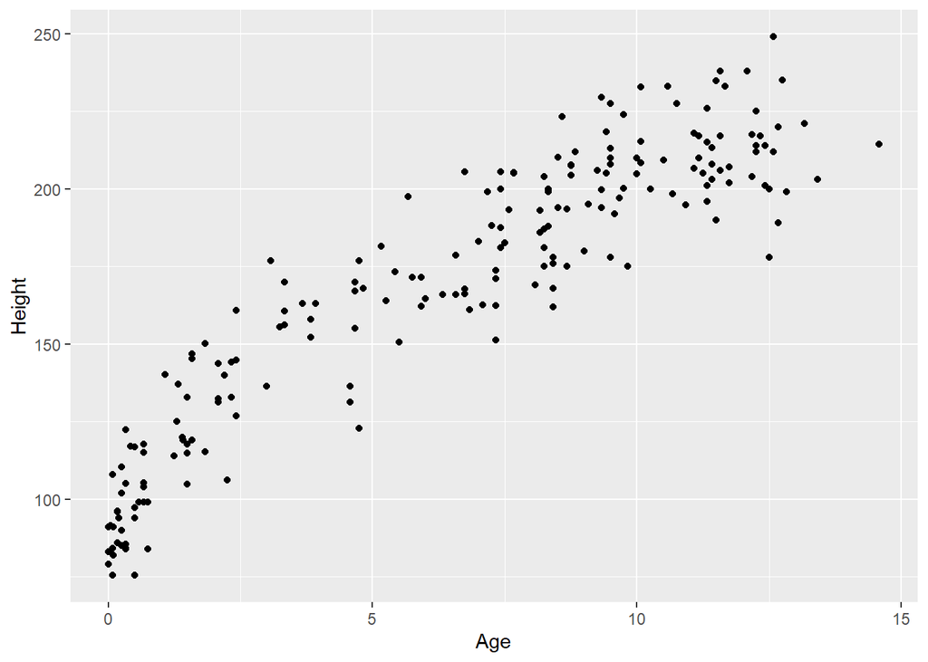

**(B)**

Produce the following data frame from Elephants_data using filter(); you need to identify the observations for where it is TRUE that the Sex is female

```
## # A tibble: 150 x 3
##      Age Height Sex
##    <dbl>  <dbl> <chr>
##  1 11.1   218.  F
##  2  2.33  133.  F
##  3  2.42  145.  F
##  4 26.5   206.  F
##  5 11.8   207   F
##  6  0.33   85.6 F
##  7 26.8   227.  F
##  8 13.4   203   F
##  9 28.4   228.  F
## 10  2.08  131.  F
## # i 140 more rows
```

**(C)**

Prepare a new script and import the IRIS.csv data.

The Iris dataset is from R.A. Fisher’s classic 1936 paper, “The Use of Multiple Measurements in Taxonomic Problems”. These are data on iris species with 50 samples each as well as some properties of each flower. One flower species is linearly separable from the other two, but the other two are not linearly separable from each other.

The column names in this dataset are:

SepalLength

SepalWidth

PetalLength

PetalWidth

Species

Import these data and follow the instruction below to produce the following output.

Don’t forget to start your script with “##” for annotating your codes for loading packages, data import, and checking the data.

Make sure you have these annotated sections, and save this script!

Filter the data so that there are only

• Iris-setosa

• petal_width of 0.2 cm

• petal_length greater than or equal to 1.3

Expected outputs

```
## Rows: 150
## Columns: 5
## $ sepal_length <dbl> 5.1, 4.9, 4.7, 4.6, 5.0, 5.4, 4.6, 5.0, 4.4, 4.9, 5.4, 4.~
## $ sepal_width  <dbl> 3.5, 3.0, 3.2, 3.1, 3.6, 3.9, 3.4, 3.4, 2.9, 3.1, 3.7, 3.~
## $ petal_length <dbl> 1.4, 1.4, 1.3, 1.5, 1.4, 1.7, 1.4, 1.5, 1.4, 1.5, 1.5, 1.~
## $ petal_width  <dbl> 0.2, 0.2, 0.2, 0.2, 0.2, 0.4, 0.3, 0.2, 0.2, 0.1, 0.2, 0.~
## $ species      <chr> "Iris-setosa", "Iris-setosa", "Iris-setosa", "Iris-setosa~
```

```
## # A tibble: 25 x 5
##    sepal_length sepal_width petal_length petal_width species
##           <dbl>       <dbl>        <dbl>       <dbl> <chr>
##  1          5.1         3.5          1.4         0.2 Iris-setosa
##  2          4.9         3            1.4         0.2 Iris-setosa
##  3          4.7         3.2          1.3         0.2 Iris-setosa
##  4          4.6         3.1          1.5         0.2 Iris-setosa
##  5          5           3.6          1.4         0.2 Iris-setosa
##  6          5           3.4          1.5         0.2 Iris-setosa
##  7          4.4         2.9          1.4         0.2 Iris-setosa
##  8          5.4         3.7          1.5         0.2 Iris-setosa
##  9          4.8         3.4          1.6         0.2 Iris-setosa
## 10          5.4         3.4          1.7         0.2 Iris-setosa
## # i 15 more rows
```

**Congratulations on your first script in R, here are the [solutions](https://lizzydapsy.github.io/R-course_materials/Solutions.html) to all the exercises.**

**We are now ready for the next stage.**

**Return** to the [main course page](https://lizzydapsy.github.io/R-for-Data-Analysis/README.html) and click on “Data manipulation and advanced plotting”.